# Hypothesis Testing Class Worksheet

Created by Jill E. Thomley

Thursday, April 22, 2021 @ 11:35 AM

### Packages Used

```r
library(resampledata) # Spruce dataset
library(tidyverse)
library(moments)
library(infer)
library(skimr)
```

### Spruce Dataset

Black Spruce is a species of a slow-growing coniferous tree that grows across the northern part of North America. It is commonly found on wet organic soils. In a study conducted in the 1990s, a biologist interested in factors affecting the growth of the black Spruce planted seedlings on sites located in boreal peatlands in northern Manitoba, Canada. The data set `Spruce` contains a part of the data from the study. Seventy-two black Spruce seedlings were planted in four plots under varying conditions and their heights and diameters were measured over the course of 5 years. The researcher wanted to see whether the addition of fertilizer or the removal of competing from other plants (by weeding) affected the growth of these seedlings.

Normally we would analyze these data using analysis of variance (ANOVA) in order to compare the four groupings formed by all combination of the two treatments (CC/FF, CC/NF, NC/FF, NC/NF). However, here we will be considering each treatment separately as an exercise in comparing two means.

- `Tree` = Tree number
- `Competition` = C (competition) or CR (competition removed)
- `Fertilizer` = F (fertilized) or NF (not fertilized)
- `Height0` = Height (cm) of seedling at planting
- `Height5` = Height (cm) of seedling at year 5
- `Diameter0` = Diameter (cm) of seedling at planting
- `Diameter5` = Diameter (cm) of seedling at year 5
- `Ht.change` = Change (cm) in height
- `Di.change` = Change (cm) in diameter

```r
spruce <- Spruce %>%
  mutate(Fertilizer = ifelse(Fertilizer == "F", "FF", "NF"), # since F = FALSE in R
         Competition = ifelse(Competition == "C", "CC", "NC"))
```

### Addition of Fertilizer

#### EDA

##### Summaries

```r
# skimr has the function skim_without_charts()
spruce %>%
  group_by(Fertilizer) %>%
  skim_without_charts(Ht.change, Di.change)
```

Data summary

| Name | Piped data |
| --- | --- |
| Number of rows | 72 |
| Number of columns | 9 |
| _______________________ |  |
| Column type frequency: |  |
| numeric | 2 |
| ________________________ |  |
| Group variables | Fertilizer |

**Variable type: numeric**

| skim_variable | Fertilizer | n_missing | complete_rate | mean | sd | p0 | p25 | p50 | p75 | p100 |
| --- | --- | --- | --- | --- | --- | --- | --- | --- | --- | --- |
| Ht.change | FF | 0 | 1 | 38.29 | 7.98 | 27.40 | 30.73 | 37.35 | 44.78 | 51.50 |
| Ht.change | NF | 0 | 1 | 23.58 | 8.53 | 8.30 | 17.47 | 23.10 | 28.62 | 45.50 |
| Di.change | FF | 0 | 1 | 5.27 | 1.38 | 2.91 | 4.32 | 4.76 | 6.52 | 8.92 |
| Di.change | NF | 0 | 1 | 2.72 | 1.10 | 1.02 | 1.92 | 2.71 | 3.16 | 5.71 |

```r
spruce %>% count(Fertilizer)
```

```
  Fertilizer  n
1         FF 36
2         NF 36
```

##### Boxplots

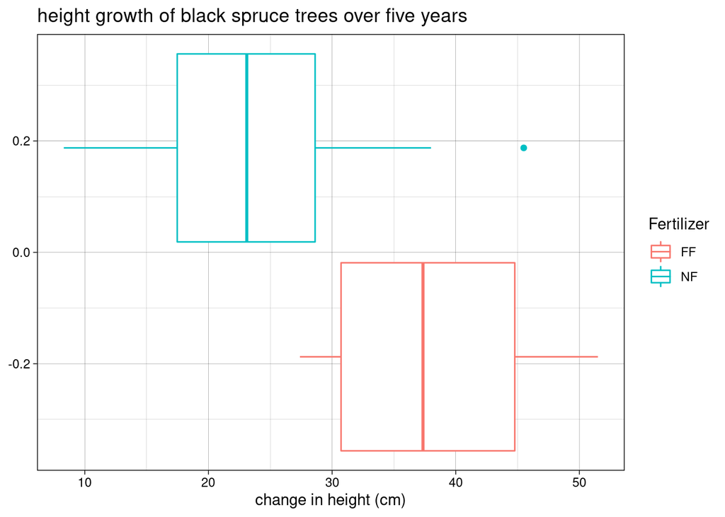

```r
ggplot(spruce, aes(x = Ht.change, color = Fertilizer)) +
  geom_boxplot() +
  labs(title = "height growth of black spruce trees over five years",
       x = "change in height (cm)") +
  theme_linedraw()
```

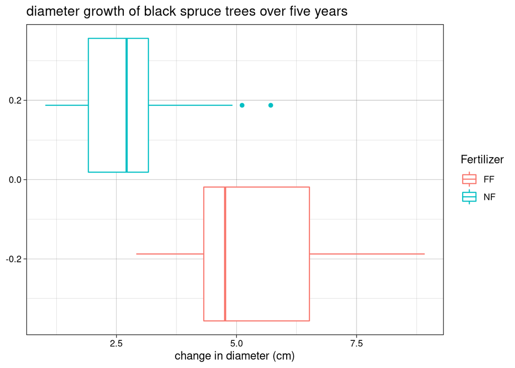

```r
ggplot(spruce, aes(x = Di.change, color = Fertilizer)) +
  geom_boxplot() +
  labs(title = "diameter growth of black spruce trees over five years",
       x = "change in diameter (cm)") +
  theme_linedraw()
```

##### Histograms

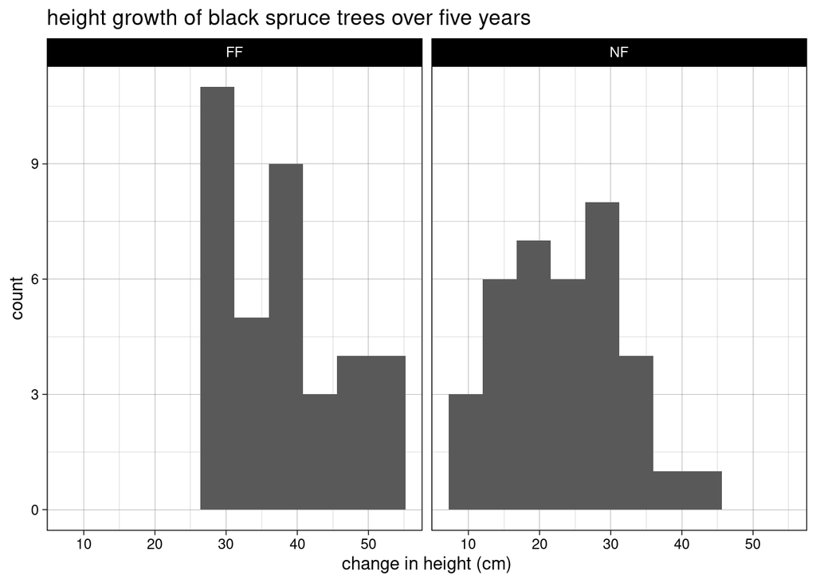

```r
ggplot(spruce, aes(x = Ht.change)) +
  geom_histogram(bins = 10) +
  facet_wrap(~ Fertilizer) +
  labs(title = "height growth of black spruce trees over five years",
       x = "change in height (cm)") +
  theme_linedraw()
```

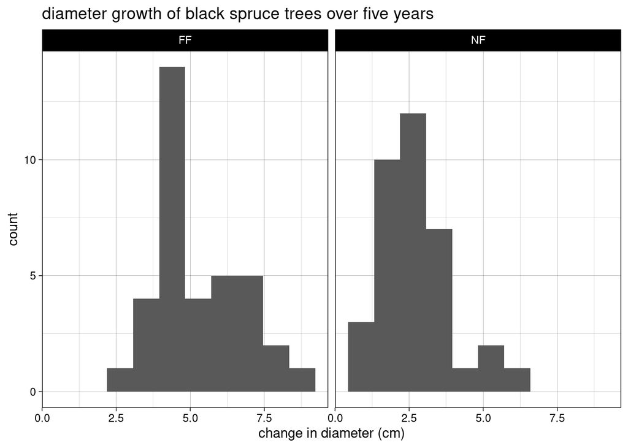

```r
ggplot(spruce, aes(x = Di.change)) +
  geom_histogram(bins = 10) +
  facet_wrap(~ Fertilizer) +
  labs(title = "diameter growth of black spruce trees over five years",
       x = "change in diameter (cm)") +
  theme_linedraw()
```

##### Normality

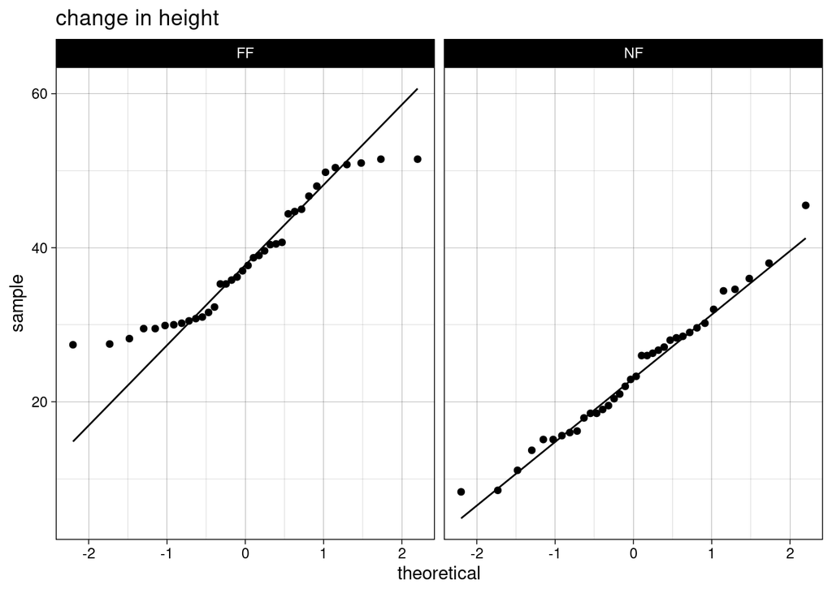

```r
ggplot(spruce, aes(sample = Ht.change)) +
  geom_qq() +
  geom_qq_line() +
  labs(title = "change in height") +
  facet_wrap(~ Fertilizer) +
  theme_linedraw()
```

```r
spruce %>%
  group_by(Fertilizer) %>%
  summarize(skew = skewness(Ht.change),
            kurt = kurtosis(Ht.change))
```

```
# A tibble: 2 x 3
  Fertilizer  skew  kurt
  <chr>      <dbl> <dbl>
1 FF         0.329  1.79
2 NF         0.310  2.79
```

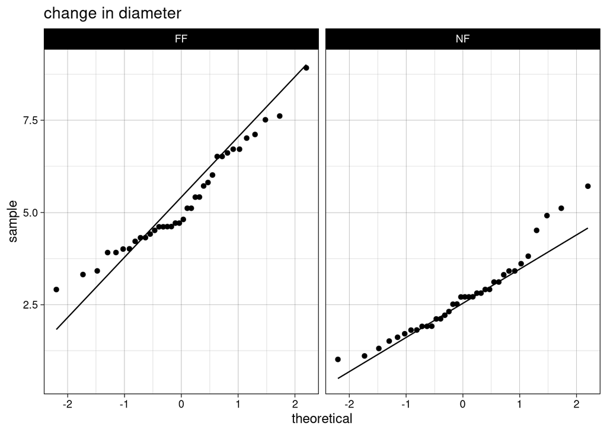

```r
ggplot(spruce, aes(sample = Di.change)) +
  geom_qq() +
  geom_qq_line() +
  labs(title = "change in diameter") +
  facet_wrap(~ Fertilizer) +
  theme_linedraw()
```

```r
spruce %>%
  group_by(Fertilizer) %>%
  summarize(skew = skewness(Di.change),
            kurt = kurtosis(Di.change))
```

```
# A tibble: 2 x 3
  Fertilizer  skew  kurt
  <chr>      <dbl> <dbl>
1 FF         0.605  2.76
2 NF         0.883  3.53
```

#### Research Question #1

Is the overall change in height different between the fertilized and unfertilized groups?

##### Hypotheses

Ho:

Ha:

##### Test Statistic

##### Null Distribution

##### Calculate P-Value

##### Decision & Answer

Do you reject Ho?

What is the answer to the question?

#### Research Question #2

Is the overall change in diameter different between the fertilized and unfertilized groups?

##### Hypotheses

Ho:

Ha:

##### Test Statistic

##### Null Distribution

##### Calculate P-Value

##### Decision & Answer

Do you reject Ho?

What is the answer to the question?

### Competition Reduction

#### EDA

##### Summaries

```r
spruce %>%
  group_by(Competition) %>%
  skim_without_charts(Ht.change, Di.change)
```

Data summary

| Name | Piped data |
| --- | --- |
| Number of rows | 72 |
| Number of columns | 9 |
| _______________________ |  |
| Column type frequency: |  |
| numeric | 2 |
| ________________________ |  |
| Group variables | Competition |

**Variable type: numeric**

| skim_variable | Competition | n_missing | complete_rate | mean | sd | p0 | p25 | p50 | p75 | p100 |
| --- | --- | --- | --- | --- | --- | --- | --- | --- | --- | --- |
| Ht.change | CC | 0 | 1 | 25.70 | 10.06 | 8.30 | 17.93 | 27.45 | 30.85 | 51.50 |
| Ht.change | NC | 0 | 1 | 36.16 | 9.49 | 17.90 | 28.82 | 35.55 | 44.78 | 51.50 |
| Di.change | CC | 0 | 1 | 3.21 | 1.46 | 1.02 | 1.92 | 2.86 | 4.44 | 7.02 |
| Di.change | NC | 0 | 1 | 4.78 | 1.75 | 1.92 | 3.26 | 4.71 | 6.14 | 8.92 |

```r
spruce %>% count(Competition)
```

```
  Competition  n
1          CC 36
2          NC 36
```

##### Boxplots

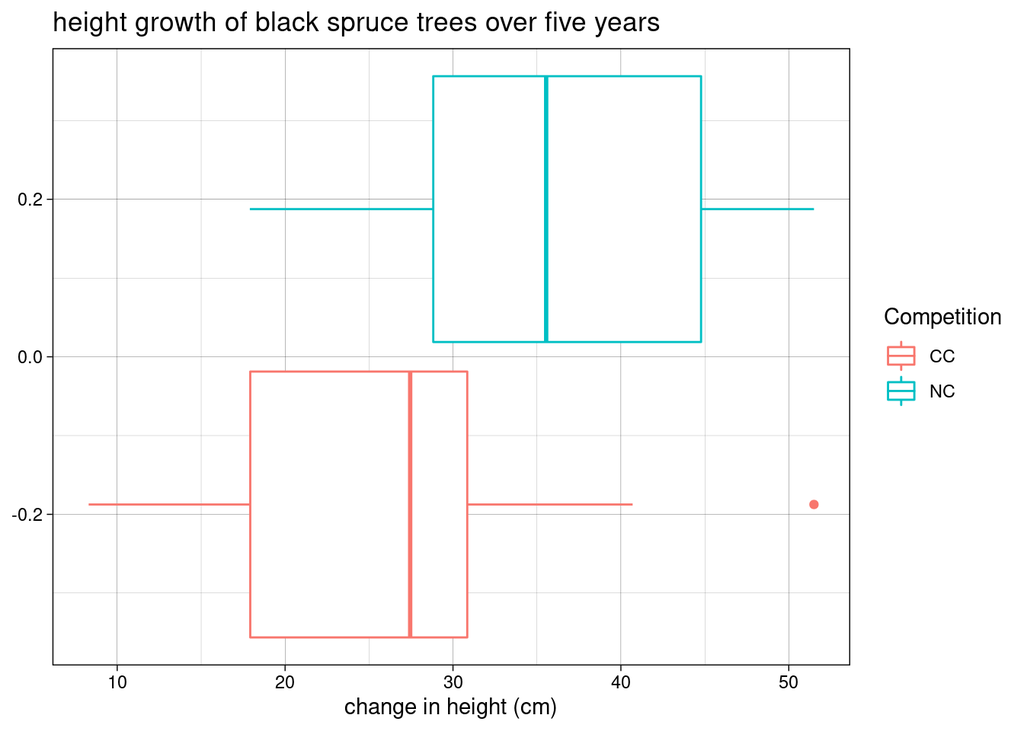

```r
ggplot(spruce, aes(x = Ht.change, color = Competition)) +
  geom_boxplot() +
  labs(title = "height growth of black spruce trees over five years",
       x = "change in height (cm)") +
  theme_linedraw()
```

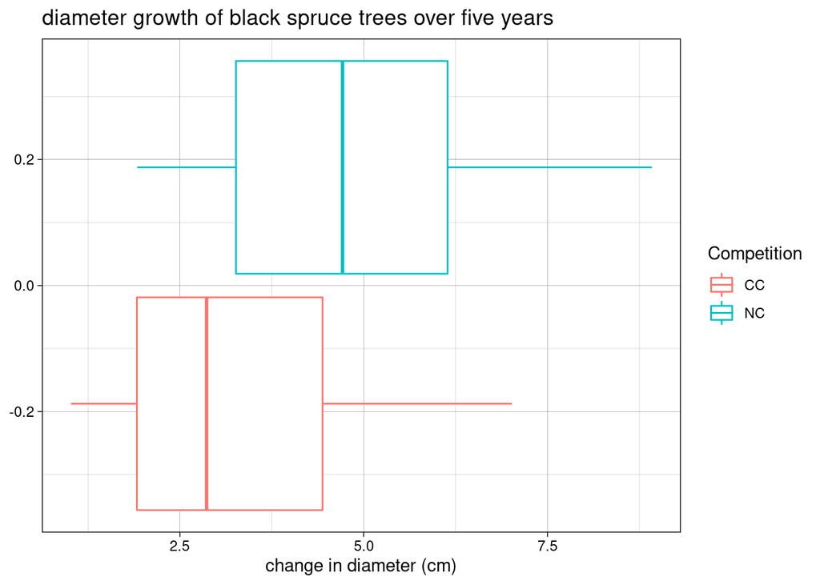

```r
ggplot(spruce, aes(x = Di.change, color = Competition)) +
  geom_boxplot() +
  labs(title = "diameter growth of black spruce trees over five years",
       x = "change in diameter (cm)") +
  theme_linedraw()
```

##### Histograms

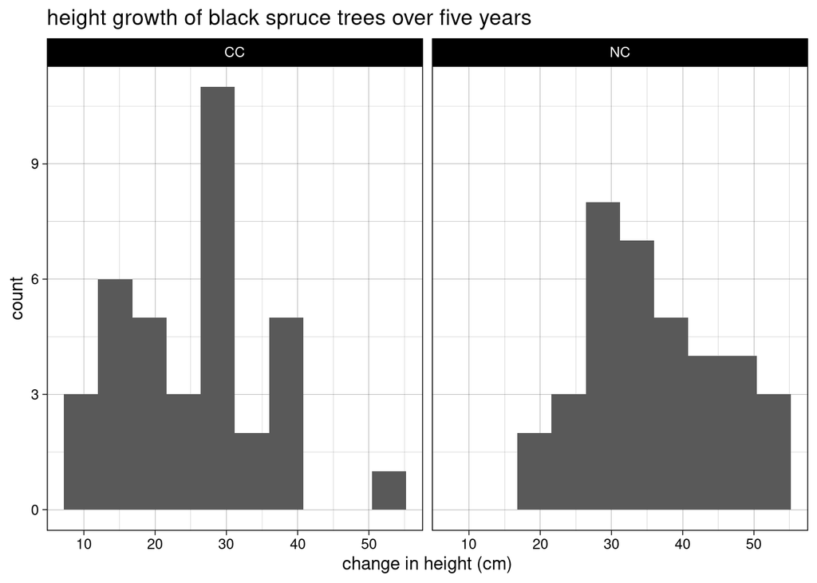

```r
ggplot(spruce, aes(x = Ht.change)) +
  geom_histogram(bins = 10) +
  facet_wrap(~ Competition) +
  labs(title = "height growth of black spruce trees over five years",
       x = "change in height (cm)") +
  theme_linedraw()
```

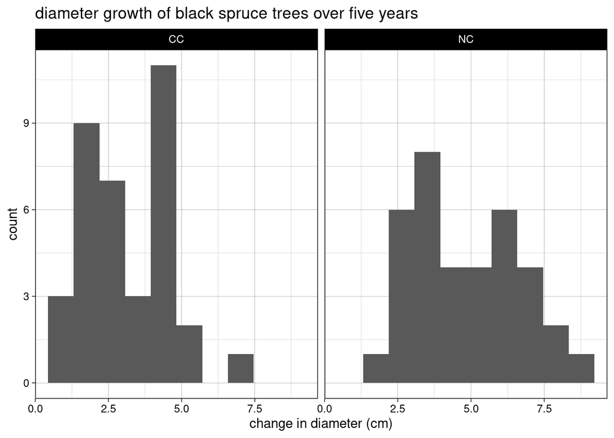

```r
ggplot(spruce, aes(x = Di.change)) +
  geom_histogram(bins = 10) +
  facet_wrap(~ Competition) +
  labs(title = "diameter growth of black spruce trees over five years",
       x = "change in diameter (cm)") +
  theme_linedraw()
```

##### Normality

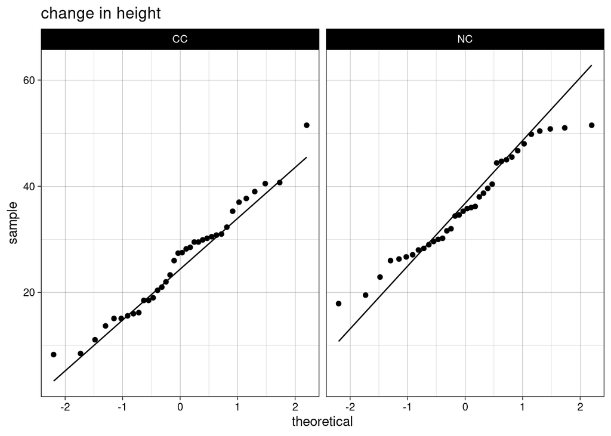

```r
ggplot(spruce, aes(sample = Ht.change)) +
  geom_qq() +
  geom_qq_line() +
  facet_wrap(~ Competition) +
  labs(title = "change in height") +
  theme_linedraw()
```

```r
spruce %>%
  group_by(Competition) %>%
  summarize(skew = skewness(Ht.change),
            kurt = kurtosis(Ht.change))
```

```
# A tibble: 2 x 3
  Competition   skew  kurt
  <chr>        <dbl> <dbl>
1 CC          0.268   2.67
2 NC          0.0718  2.00
```

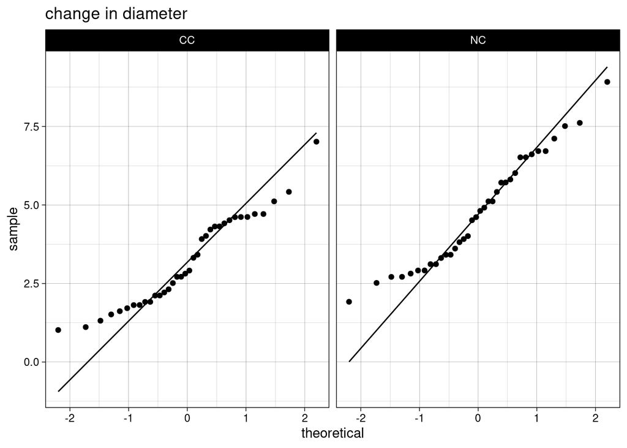

```r
ggplot(spruce, aes(sample = Di.change)) +
  geom_qq() +
  geom_qq_line() +
  labs(title = "change in diameter") +
  facet_wrap(~ Competition) +
  theme_linedraw()
```

```r
spruce %>%
  group_by(Competition) %>%
  summarize(skew = skewness(Di.change),
            kurt = kurtosis(Di.change))
```

```
# A tibble: 2 x 3
  Competition  skew  kurt
  <chr>       <dbl> <dbl>
1 CC          0.408  2.42
2 NC          0.360  2.18
```

#### Question #3

Did eliminating competition produce a greater change in height than the control condition?

##### Hypotheses

Ho:

Ha:

##### Test Statistic

##### Null Distribution

##### Calculate P-Value

##### Decision & Answer

Do you reject Ho?

What is the answer to the question?

#### Question #4

Did eliminating competition produce a greater change in diameter than the control condition?

##### Hypotheses

Ho:

Ha:

##### Test Statistic

##### Null Distribution

##### Calculate P-Value

##### Decision & Answer

Do you reject Ho?

What is the answer to the question?